# Prediction of protein pocket druggability

# Chapter 2 : Analysis of the data

# 2.1 Preparation of the data

1. Open the file descriptor_pocket.mat containing the dataset.

```r
pockets = read.table("descriptor_pocket.mat")
names(pockets)
```

```
 [1] "C_ATOM"                            "A"                                 "C"
 [4] "E"                                 "D"                                 "G"
 [7] "F"                                 "I"                                 "H"
[10] "K"                                 "M"                                 "L"
[13] "N"                                 "Q"                                 "P"
[16] "S"                                 "R"                                 "T"
[19] "W"                                 "V"                                 "Y"
[22] "C_RESIDUES"                        "Mean_alpha.sphere_radius"          "Real_volume"
[25] "Proportion_of_apolar_alpha_sphere" "Mean_B.factor"                     "Mean_alpha.sphere_SA"
[28] "drugg"
```

2. Remove all pockets with missing values. Use the function na.omit(). How many pockets did you remove?

```r
dim(pockets)
```

```
[1] 112  28
```

```r
#is.na(pockets)
pockets = na.omit(pockets)
dim(pockets)
```

```
[1] 109  28
```

# 2.2 Computation of new variables

In this dataset, the composition of pockets is described using the frequency of 20 amino acids. However, it would be interesting to work with the amino acid classes: • aromatic residues: F, Y, H, W • polar residues: C, D,E, H, K, N, Q, R, S, T, W, Y • aliphatic residues: I, L, V • charged residues: D,E, R, K, H • negative residues: D, E • positive residues: H, K, R • hydrophobic residues: C, G, A, T, V, L, I, M, F, W, Y, H, K • small residues C, V, T, G, A, S, D, N, P • tiny residues: A, C, G, S 1. Based on the class definition and the amino acid frequencies, compute the frequency of each class in the pocket dataset. 2. Add these new variables to the dataset. How many descriptors does your dataset contain?

```r
aromatic = apply(cbind(pockets$F, pockets$Y, pockets$H, pockets$W), 1, sum)
polar = apply(cbind(pockets$C, pockets$D, pockets$E, pockets$H, pockets$K, pockets$N, pockets$Q, pockets$R, pockets$S, pockets$T, pockets$W, pockets$Y), 1, sum)
aliphatic = apply(cbind(pockets$I, pockets$L, pockets$V), 1, sum)
charged = apply(cbind(pockets$D, pockets$E, pockets$R, pockets$K, pockets$H), 1, sum)
negative = apply(cbind(pockets$D, pockets$E), 1, sum)
positive = apply(cbind(pockets$R, pockets$K, pockets$H), 1, sum)
hydrophobic = apply(cbind(pockets$C, pockets$G, pockets$A, pockets$T, pockets$V, pockets$L, pockets$I, pockets$M, pockets$F, pockets$W, pockets$H, pockets$Y, pockets$K), 1, sum)
small = apply(cbind(pockets$C, pockets$G, pockets$A, pockets$T, pockets$V, pockets$S, pockets$D, pockets$N, pockets$P), 1, sum)
tiny = apply(cbind(pockets$A, pockets$C, pockets$G, pockets$S), 1, sum)
pockets = cbind(pockets, aromatic, polar, aliphatic, charged, negative, positive, hydrophobic, small, tiny)
#mise de "drugg" à la fin du tableau
noms = names(pockets)
pockets = cbind(pockets[,1:27], pockets[,29:37], pockets[,28])
colnames(pockets)[37] = noms[28]
names(pockets)   #37 descriptors
```

```
 [1] "C_ATOM"                            "A"                                 "C"
 [4] "E"                                 "D"                                 "G"
 [7] "F"                                 "I"                                 "H"
[10] "K"                                 "M"                                 "L"
[13] "N"                                 "Q"                                 "P"
[16] "S"                                 "R"                                 "T"
[19] "W"                                 "V"                                 "Y"
[22] "C_RESIDUES"                        "Mean_alpha.sphere_radius"          "Real_volume"
[25] "Proportion_of_apolar_alpha_sphere" "Mean_B.factor"                     "Mean_alpha.sphere_SA"
[28] "aromatic"                          "polar"                             "aliphatic"
[31] "charged"                           "negative"                          "positive"
[34] "hydrophobic"                       "small"                             "tiny"
[37] "drugg"
```

# 2.3

## 2.3.1Analysis of the dataset

## Comparison of druggable and less druggable pockets

1. Which type of variables (quantitative, qualitative) does the dataset contain?
2. Plot the distribution of all descriptors using the function boxplot(). What do you ob- serve?

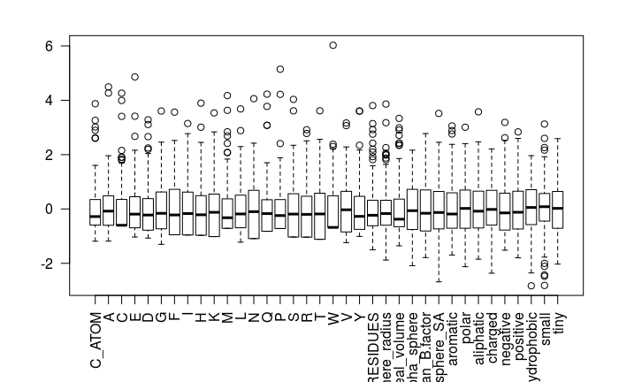

```r
boxplot(scale(pockets[,-37]), las=2)
```

3. Plot the distribution of all descriptors in druggable pockets and in less druggable pockets. What do you observe?

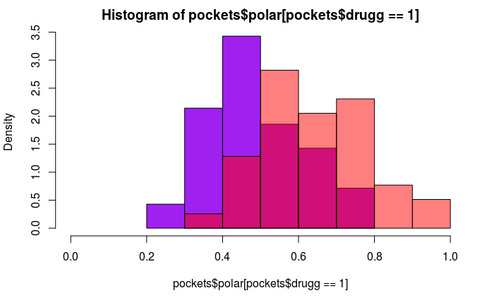

```r
#ma version
hist(pockets$polar[pockets$drugg == 1], freq=F, col = "purple", xlim = c(0, 1))
hist(pockets$polar[pockets$drugg == 0], freq=F, col =rgb(1,0,0,0.5), add=T)
```

```r
#version prof
# par(mfrow = c(1, 2))
# for (i in c(1:36))
#     by(pockets[,i], pockets$drugg, hist, main = "un histogramme")
```

4. Compute the mean and the standard deviation values of each descriptor and in druggable and less druggable pockets. What do you observe?

```r
#ma version
# for (i in 1:36){
#     print(mean(pockets[,i][pockets$drugg == 1]))
#     print(mean(pockets[,i][pockets$drugg == 0]))
#     print(sd(pockets[,i][pockets$drugg == 1]))
#     print(sd(pockets[,i][pockets$drugg == 0]))
# }
#version prof
# lapply(pockets, mean)
# lapply(pockets, sd)
print(means <- aggregate(pockets[,-37], by=list(pockets$drugg), FUN = mean))
```

| Group.1 | C_ATOM | A | C | E | D | G | F | I | H | K | M | L | N | Q | P | S | R | T | W | V | Y | C_RESIDUES | Mean_alpha.sphere_radius | Real_volume | Proportion_of_apolar_alpha_sphere | Mean_B.factor | Mean_alpha.sphere_SA | aromatic | polar | … |
| --- | --- | --- | --- | --- | --- | --- | --- | --- | --- | --- | --- | --- | --- | --- | --- | --- | --- | --- | --- | --- | --- | --- | --- | --- | --- | --- | --- | --- | --- | --- |
| 0 | 78.07692 | 0.05114319 | 0.02002454 | 0.06629069 | 0.07669897 | 0.09349549 | 0.02257796 | 0.02891320 | 0.04960749 | 0.04810756 | 0.02050263 | 0.05144757 | 0.05833306 | 0.04753507 | 0.04096838 | 0.06163518 | 0.08641373 | 0.05538725 | 0.03475484 | 0.04324497 | 0.04291823 | 27.89744 | 3.859477 | 1066.982 | 0.2805333 | 0.2195231 | 0.4959154 | 0.1498585 | 0.6477066 | … |
| 1 | 95.11429 | 0.06171481 | 0.02279384 | 0.04977660 | 0.05309277 | 0.07933909 | 0.05294081 | 0.05661999 | 0.04131254 | 0.03645621 | 0.04539694 | 0.11233321 | 0.03343820 | 0.03314290 | 0.02499526 | 0.05220536 | 0.03939128 | 0.04796180 | 0.02009648 | 0.07560594 | 0.06138598 | 33.02857 | 3.897803 | 1290.532 | 0.5029414 | 0.2049557 | 0.4915057 | 0.1757358 | 0.4910540 | … |

```r
print(sds <- aggregate(pockets[,-37], by=list(pockets$drugg), FUN = sd))
```

| Group.1 | C_ATOM | A | C | E | D | G | F | I | H | K | M | L | N | Q | P | S | R | T | W | V | Y | C_RESIDUES | Mean_alpha.sphere_radius | Real_volume | Proportion_of_apolar_alpha_sphere | Mean_B.factor | Mean_alpha.sphere_SA | aromatic | polar | … |
| --- | --- | --- | --- | --- | --- | --- | --- | --- | --- | --- | --- | --- | --- | --- | --- | --- | --- | --- | --- | --- | --- | --- | --- | --- | --- | --- | --- | --- | --- | --- |
| 0 | 56.57244 | 0.05105992 | 0.03894484 | 0.06640982 | 0.06434049 | 0.07611388 | 0.03505939 | 0.03125006 | 0.0471546 | 0.04558146 | 0.04847251 | 0.05139685 | 0.04506545 | 0.05536686 | 0.05088463 | 0.06552517 | 0.06496214 | 0.04759453 | 0.04830484 | 0.04797480 | 0.04870474 | 18.29552 | 0.2724085 | 766.9849 | 0.1021007 | 0.1316525 | 0.04570394 | 0.08798151 | 0.1347543 | … |
| 1 | 57.21015 | 0.04764547 | 0.03496317 | 0.04511657 | 0.05173135 | 0.05762710 | 0.04538834 | 0.05383518 | 0.0449210 | 0.03606797 | 0.05077279 | 0.07619005 | 0.03187134 | 0.04048200 | 0.03641642 | 0.04624282 | 0.03839674 | 0.04407129 | 0.02850610 | 0.05015491 | 0.05624911 | 17.82765 | 0.2432807 | 776.4716 | 0.1615107 | 0.1093990 | 0.03298879 | 0.10289490 | 0.1286067 | … |

5. Compare the mean values of each descriptor in druggable pockets and less druggable pockets. How many descriptors have the same mean in the 2 groups? Which are the descriptors that separate better druggable and less druggable pockets?

## 2.3.2 Correlation between descriptors

1. Compute the correlation between descriptors.

```r
pockets.pvalues = c()
for (i in 1:36){
# Optionnel, il faudrait comparer les variances, comme condition d'application du Student
#    var.test(pockets[,i][pockets$drugg == 1], pockets[,i][pockets$drugg == 0])
    pvalue = t.test(pockets[,i][pockets$drugg == 1], pockets[,i][pockets$drugg == 0])$p.value
    pockets.pvalues = c(pockets.pvalues, pvalue)
}
pockets.pvalues
```

```
 [1] 1.372929e-01 2.921345e-01 7.132862e-01 1.713497e-01 5.369595e-02 3.158105e-01 1.852978e-04 9.515513e-04 3.734754e-01 1.740272e-01
[11] 1.344103e-02 2.785852e-06 3.404212e-03 1.592683e-01 8.892371e-02 4.296866e-01 1.265290e-04 4.254184e-01 8.867286e-02 1.342559e-03
[21] 7.630023e-02 1.606834e-01 4.671185e-01 1.503770e-01 3.070016e-14 5.590155e-01 5.977421e-01 1.698849e-01 9.102372e-08 6.708524e-11
[31] 1.647504e-06 1.451016e-02 3.992260e-05 6.496233e-09 5.944650e-02 6.377463e-01
```

2. Represent the correlation matrix in a graphic. Which descriptors are the most correlated? What does it mean?
3. Plot (scatter-plot) the volume of each pocket (descriptor Real_volume) in function of its number of atoms (descriptor C_atom). Are these two descriptors significantly correlated?

```r
# drug.corr = cor(pockets[,-37])
# library(corrplot)
# corrplot(drug.corr)
# plot(pockets$polar, pockets$hydrophobic)
# plot(pockets$Real_volume, pockets$C_ATOM)
```

4. Compute the linear regression to predict the pocket volume knowing its number of atoms.
5. Add on the scatterplot the regression line.
6. Analyze the models (residues, performances)
7. Predict the volume of the pockets containing 50, 200, 159 and 450 atoms. All these steps allow obtaining a cleaned dataset. Now, you can begin the analysis of de- scriptors computed on druggable and less druggable pockets.